# atc_medicare_merge

darya akimova

February 5, 2018

The goal of this work is to merge the drug names from the Medicare Part D spending data with the ATC classifications system, based on drug names. Anticipating having to clean both sets of names to get them to merge.

Packages:

```r
library(tidyverse)
library(cowplot)
library(data.world)
```

Data:

```r
drug.spend.ds <- "https://data.world/data4democracy/drug-spending"
# drug names from Medicare Part D data:
d.drugs <- data.world::query(
  data.world::qry_sql("SELECT DISTINCT brand_name, generic_name FROM `spending_part_d_2011to2015_tidy`"),
  dataset = drug.spend.ds
  ) %>%
  mutate_all(str_trim)  # just in case
glimpse(d.drugs)
```

```
## Observations: 4,498
## Variables: 2
## $ brand_name   <chr> "sodium chloride", "procalamine", "zytiga", "azor...
## $ generic_name <chr> "0.9 % sodium chloride", "aa 3%/electrolyte-tpn s...
```

```r
# atc classification system from drug_uses.csv
atc <- data.world::query(
  data.world::qry_sql("SELECT * FROM drug_uses"),
  dataset = drug.spend.ds
)
glimpse(atc)
```

```
## Observations: 6,183
## Variables: 9
## $ column_a         <int> 0, 1, 10, 100, 1008, 1009, 1010, 1011, 1012, ...
## $ drugname_brand   <chr> "8-MOP", "8-MOP", "ABILIFY DISCMELT", "ADRENA...
## $ drugname_generic <chr> "METHOXSALEN", "METHOXSALEN", "ARIPIPRAZOLE",...
## $ anatomical       <chr> "DERMATOLOGICALS", "DERMATOLOGICALS", "NERVOU...
## $ therapeutic      <chr> "ANTIPSORIATICS", "ANTIPSORIATICS", "PSYCHOLE...
## $ pharmacologic    <chr> "ANTIPSORIATICS FOR TOPICAL USE", "ANTIPSORIA...
## $ chemical         <chr> "PSORALENS FOR TOPICAL USE", "PSORALENS FOR S...
## $ substance        <chr> "METHOXSALEN", "METHOXSALEN", "ARIPIPRAZOLE",...
## $ name             <chr> "METHOXSALEN", "METHOXSALEN", "ARIPIPRAZOLE L...
```

The ATC datasets needs some cleaning up:

```r
atc <- atc %>%
  select(-column_a) %>% # not useful
  select(starts_with("drug"), substance, name, everything()) %>%
  mutate_all(str_to_lower) %>%
  mutate_all(str_trim) %>%
  # rename some variables for clarity
  rename(
    first_level = anatomical,
    second_level = therapeutic,
    third_level = pharmacologic,
    fourth_level = chemical
    )
glimpse(atc)
```

```
## Observations: 6,183
## Variables: 8
## $ drugname_brand   <chr> "8-mop", "8-mop", "abilify discmelt", "adrena...
## $ drugname_generic <chr> "methoxsalen", "methoxsalen", "aripiprazole",...
## $ substance        <chr> "methoxsalen", "methoxsalen", "aripiprazole",...
## $ name             <chr> "methoxsalen", "methoxsalen", "aripiprazole l...
## $ first_level      <chr> "dermatologicals", "dermatologicals", "nervou...
## $ second_level     <chr> "antipsoriatics", "antipsoriatics", "psychole...
## $ third_level      <chr> "antipsoriatics for topical use", "antipsoria...
## $ fourth_level     <chr> "psoralens for topical use", "psoralens for s...
```

```r
# it looks like drugname_generic and substance might be identical columns, is this true?
all.equal(atc$drugname_generic, atc$substance)  # yes
```

```
## [1] TRUE
```

```r
# remove the substance column, rename the `name` column appropriately to what it really is - the chemical formulation
atc <- atc %>%
  select(-substance) %>%
  rename(
    chem_formula = name
  )
glimpse(atc)
```

```
## Observations: 6,183
## Variables: 7
## $ drugname_brand   <chr> "8-mop", "8-mop", "abilify discmelt", "adrena...
## $ drugname_generic <chr> "methoxsalen", "methoxsalen", "aripiprazole",...
## $ chem_formula     <chr> "methoxsalen", "methoxsalen", "aripiprazole l...
## $ first_level      <chr> "dermatologicals", "dermatologicals", "nervou...
## $ second_level     <chr> "antipsoriatics", "antipsoriatics", "psychole...
## $ third_level      <chr> "antipsoriatics for topical use", "antipsoria...
## $ fourth_level     <chr> "psoralens for topical use", "psoralens for s...
```

```r
# much better
glimpse(d.drugs)
```

```
## Observations: 4,498
## Variables: 2
## $ brand_name   <chr> "sodium chloride", "procalamine", "zytiga", "azor...
## $ generic_name <chr> "0.9 % sodium chloride", "aa 3%/electrolyte-tpn s...
```

Time for some test merges - the low hanging fruit is: atc - `drugname_brand` to d.drugs - `brand_name`

```r
brand.semi <- d.drugs %>%
  semi_join(atc, by = c("brand_name" = "drugname_brand"))
dim(brand.semi)
```

```
## [1] 1241    2
```

1241 drug matches our of 4498! Not bad at all.

Will take what is left over and keep working on it:

```r
brand.anti <- d.drugs %>%
  anti_join(atc, by = c("brand_name" = "drugname_brand")) %>%
  arrange(brand_name)
glimpse(brand.anti)
```

```
## Observations: 3,257
## Variables: 2
## $ brand_name   <chr> "10 wash", "1st tier unifine pentips", "1st tier ...
## $ generic_name <chr> "sulfacetamide sodium", "pen needle, diabetic", "...
```

Future problems ahead include: - instruments vs drugs (needles, the like) - multiple drug ingredients in the generic_name column

On and further

```r
generic.semi <- brand.anti %>%
  semi_join(atc, by = c("generic_name" = "drugname_generic"))
dim(generic.semi)
```

```
## [1] 0 2
```

```r
# whump whump
chem.semi <- brand.anti %>%
  semi_join(atc, by = c("generic_name" = "chem_formula"))
dim(chem.semi)
```

```
## [1] 84  2
```

```r
chem.anti <- brand.anti %>%
  anti_join(atc, by = c("generic_name" = "chem_formula"))
dim(chem.anti)
```

```
## [1] 3173    2
```

That is 84 more than before, I suppose. A little less than what I was hoping for.

Break 1:

```r
matched.so.far <- brand.semi %>%
  bind_rows(chem.semi)
dim(matched.so.far)
```

```
## [1] 1325    2
```

```r
# write_csv(matched.so.far, "medicareD_matched_1325.csv")
# write_csv(chem.anti, "medicareD_unmatched_3173.csv")
```

Now have to start altering the Medicare Part D drug names:

```r
chem.anti <- chem.anti %>%
  mutate(alt_name = str_replace(generic_name, "hcl", "hydrochloride"))
hcl.semi <- chem.anti %>%
  semi_join(atc, by = c("alt_name" = "chem_formula"))
hcl.anti <- chem.anti %>%
  anti_join(atc, by = c("alt_name" = "chem_formula"))
dim(hcl.semi)
```

```
## [1] 38  3
```

```r
dim(hcl.anti)
```

```
## [1] 3135    3
```

```r
matched.so.far <- matched.so.far %>%
  bind_rows(hcl.semi %>% select(-alt_name))
```

A potential issue is drugs with multiple ingredients. It seems that many drugs have multiple active ingredients separted potentially by “/”, “,”, or “-” in the `generic_name` column.

```r
hcl.anti <- hcl.anti %>%
  mutate(mult.forsla = str_count(alt_name, "/"),
         mult.comm = str_count(alt_name, ","),
         mult.dash = str_count(alt_name, "-"),
         mult.all = mult.forsla + mult.comm + mult.dash)
nrow(hcl.anti %>%
       filter(mult.all > 0))
```

```
## [1] 1800
```

```r
sum(str_detect(hcl.anti$alt_name, "/")) + sum(str_detect(hcl.anti$alt_name, ",")) + sum(str_detect(hcl.anti$alt_name, "-"))
```

```
## [1] 2236
```

```r
# some names use multiple signs, for some drugs this is a sign of multiple ingredients and for others its just naming convention
```

One “/” notation that stood out for some drug names was “/pf”. Upon a little bit of research, it seems that “pf” stands for “pre-filled”, as in a pre-filled syringe (such as a vaccine).

```r
slash.pf <- hcl.anti %>% filter(str_detect(alt_name, "pf"))
nrow(slash.pf)
```

```
## [1] 90
```

```r
glimpse(slash.pf)
```

```
## Observations: 90
## Variables: 7
## $ brand_name   <chr> "acthib", "acuvail", "adacel tdap", "akten", "ast...
## $ generic_name <chr> "haemoph b poly conj-tet tox/pf", "ketorolac trom...
## $ alt_name     <chr> "haemoph b poly conj-tet tox/pf", "ketorolac trom...
## $ mult.forsla  <int> 1, 1, 1, 1, 1, 1, 1, 1, 1, 1, 1, 2, 2, 1, 1, 1, 1...
## $ mult.comm    <int> 0, 0, 2, 0, 0, 0, 1, 1, 0, 0, 0, 0, 0, 2, 0, 0, 0...
## $ mult.dash    <int> 1, 0, 0, 0, 0, 0, 0, 1, 0, 0, 0, 1, 0, 0, 0, 0, 0...
## $ mult.all     <int> 2, 1, 3, 1, 1, 1, 2, 3, 1, 1, 1, 3, 2, 3, 1, 1, 1...
```

```r
# note that "Pf", "PF", and "pF" bring up no results
nrow(slash.pf %>% filter(str_detect(alt_name, "/pf")))
```

```
## [1] 90
```

```r
# all "pf" instances are "/pf" - can remove these and maybe get a few more matches
sum(str_detect(hcl.anti$alt_name, "/"))
```

```
## [1] 1401
```

```r
hcl.anti <- hcl.anti %>%
  mutate(alt_name = str_trim(str_replace(alt_name, "/pf", "")),
         mult.forsla = str_count(alt_name, "/"),
         mult.comm = str_count(alt_name, ","),
         mult.dash = str_count(alt_name, "-"),
         mult.all = mult.forsla + mult.comm + mult.dash)
sum(str_detect(hcl.anti$alt_name, "/"))
```

```
## [1] 1319
```

```r
# some of the drugs still have "/" in the alt_name column
hcl.anti <- hcl.anti %>%
  mutate(alt_name = str_replace(alt_name, "hcl", "hydrochloride"))
# match after pf removal and second "hcl" replacement
pf.semi <- hcl.anti %>%
  semi_join(atc, by = c("alt_name" = "chem_formula")) # %>%
  #bind_rows(
   # hcl.anti %>%
    #  semi_join(atc, by = c("alt_name" = "drugname_generic")) # this result is zero
  #)
dim(pf.semi)
```

```
## [1] 8 7
```

```r
matched.so.far <- matched.so.far %>%
  bind_rows(pf.semi %>% select(brand_name, generic_name))
dim(matched.so.far)
```

```
## [1] 1371    2
```

```r
pf.anti <- hcl.anti %>%
  anti_join(atc, by = c("alt_name" = "chem_formula"))
# sanity check:
nrow(pf.anti) + nrow(matched.so.far)
```

```
## [1] 4498
```

Okay, now to start tackling some of the multiple-ingredient drugs. The “/” seems to be the easiest to tackle.

```r
table(pf.anti$mult.forsla)
```

```
##
##    0    1    2    3    4    5    6    7
## 1808  666  315  201  107   19    7    4
```

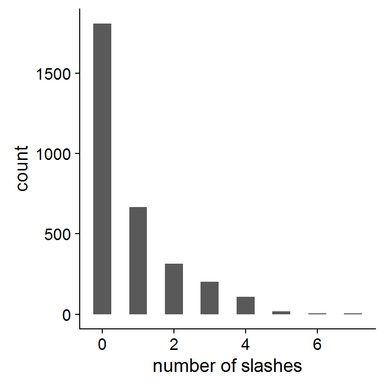

```r
pf.anti %>%
  ggplot(aes(mult.forsla)) +
    geom_histogram(binwidth = 0.5) +
    xlab("number of slashes")
```

The max number of forward slashes is 7 and 5 or greater is a small enough number of drugs to be looked at:

```r
pf.anti %>% filter(mult.forsla >= 5)
```

```
## # A tibble: 30 x 7
##    brand_name   generic_name    alt_name   mult.forsla mult.comm mult.dash
##    <chr>        <chr>           <chr>            <int>     <int>     <int>
##  1 animi-3      om-3/dha/epa/d~ om-3/dha/~           7         0         2
##  2 animi-3 wit~ om-3/dha/epa/d~ om-3/dha/~           7         0         2
##  3 calcifolic-d calcium/mag/d3~ calcium/m~           6         0         0
##  4 calcium-fol~ calcium/mag/d3~ calcium/m~           6         0         0
##  5 corvita 150  iron, carbonyl~ iron, car~           5         1         1
##  6 corvite 150  iron, carbonyl~ iron, car~           5         1         1
##  7 duet dha 400 pnv106/iron/fa~ pnv106/ir~           5         0         0
##  8 duet dha ba~ pnv105/iron/fa~ pnv105/ir~           5         0         0
##  9 duet dha ba~ pnv110/iron/fa~ pnv110/ir~           5         0         0
## 10 duet dha ba~ pnv117/iron/fa~ pnv117/ir~           5         0         0
## # ... with 20 more rows, and 1 more variable: mult.all <int>
```

Many of these seem to be multivitamins and other nutrient supplements. Although care should be taken. A drug called Enlyte, for example, looks on the surface to be a multivitamin but it turns out to be a treatment for certain kinds of depression caused by folate deficiency.

```r
pf.anti.2ingr <- pf.anti %>%
  filter(mult.forsla == 1) %>%
  select(ends_with("name")) %>%
  separate(alt_name, c("ingrd_1", "ingrd_2"), sep = "/") %>%
  gather("ingrd", "chem_name", 3:4) %>%
  mutate(chem_name = str_trim(chem_name)) %>%
  arrange(brand_name)
pf.2ingr.c.semi <- pf.anti.2ingr %>%
  semi_join(atc, by = c("chem_name" = "chem_formula"))
pf.2ingr.c.anti <- pf.anti.2ingr %>%
  anti_join(atc, by = c("chem_name" = "chem_formula"))
pf.2ingr.g.semi <- pf.2ingr.c.anti %>%
  semi_join(atc, by = c("chem_name" = "drugname_generic"))
pf.2ingr.g.anti <- pf.2ingr.c.anti %>%
  anti_join(atc, by = c("chem_name" = "drugname_generic"))
pf.2ingr.so.far <- pf.2ingr.c.semi %>%
  bind_rows(pf.2ingr.g.semi)
# matched
dim(pf.2ingr.so.far)
```

```
## [1] 313   4
```

```r
# to go
dim(pf.2ingr.g.anti)
```

```
## [1] 1019    4
```

Upon further exploration, there seems to be a problem - the `drug_uses.csv` dataset does not seem to contain the full ATC code system. That’s a problem.

# Will abandon this attempt to merge the medicare part d data with the `drug_uses.csv` file. Will start over with `atc_codes_clean.csv`.